# OD PROJECT - First Delivery

## Group 14

### Madalena Sampaio 93294

### Maria Cardoso 93661

### João Rosado 96409

## Introduction

In this report, we will solve the first part of the project for the Optimization and Decision course. We will address the **CVRP (Capacitated Vehicle Routing Problem)** using the **Simplex** Method. For this problem to be compatible with the Simplex Method, we must simplify it and formulate it as a **Linear Programming** (LP) problem.

The Capacitated Vehicle Routing Problem (CVRP) is a classic optimization problem in logistics and operations research. It involves determining the most efficient routes for a fleet of vehicles to deliver goods to a set of destinations, while considering capacity constraints on each vehicle. Each route visits a subset of nodes and starts and terminates at the depot (here represented by node 1).

The objective is to minimize the total distance or cost of all routes while ensuring that the demands of all destinations are met without exceeding the truck capacities, withouth specifying the number of trucks to be used.

### Defining the Problem

For it to be seen as a Linear Programming (LP) Simplex problem we must find the expression for **the value that we intend to minimize** and the **problem constraints**. Those are the following:

Let x<sub>*kij*</sub> be a binary decision variable defined to indicate whether the vehicle *k*, *k* ∈ {1, 2, ..., p}, traverses an arc (*i*, *j*) in an optimal solution (1 if it is, 0 if it is not), c<sub>*ij*</sub> representing the travelling distance from node *i* to node *j* and q<sub>*j*</sub> ≤ *Q* depicting the demand at destination node *j*. Each vehicle has a maximum capacity *Q* in terms of the total demand it can serve. The minimum number of vehicles needed to serve all customers is $$ \left\lceil \frac{\sum_{i=1}^{n} q_{i}}{Q} \right\rceil $$ Although this number does not necessarily represent the optimal number of vehicles required to satisfy the goal of this study.

The objective function is to **minimize** the total distance of each route while covering the demands of every node/costumer:

$$ \sum_{k=1}^{p}\sum_{i=1}^{n}\sum_{j=1,i\neq j}^{n} c_{ij} \: x_{kij} $$

subject to the following constraints:

**Capacity Constraint**

1. The sum of the demands of the nodes visited in a route is less than or equal to the capacity of the vehicle performing the service: $$ \sum_{i=1}^{n}\sum_{j=2,i\neq j}^{n} q_{j} \: x_{kij} \leq Q \quad , \quad \forall k \in \{1, \dots, p\} $$

**Routing Constraint**

2. Each node is visited by exactly one vehicle:
   $$ \sum_{k=1}^{p}\sum_{i=1,i\neq j}^{n} x_{kij} = 1 \quad , \quad \forall j \in \{1, \dots, n\} $$

**Depot Constraint**

3. Each vehicle must start from the depot node:
   $$ \sum_{j=2}^{n} x_{k1j} = 1 \quad , \quad \forall k \in \{1, \dots, p\} $$
4. Each vehicle must terminate at the depot node:
   $$ \sum_{i=2}^{n} x_{ki1} = 1 \quad , \quad \forall k \in \{1, \dots, p\} $$

**Flow Constraint**

5. The number of the vehicles arriving at every customer and entering the depot is equal to the number of the vehicles leaving:
   $$ \sum_{i=1,i\neq j}^{n} x_{kij} = \sum_{i=1}^{n} x_{kji} \quad , \quad \forall j \in \{1, \dots, n\}, \: k \in \{1, \dots, p\} $$

**Obligatory Constraint**

6. Specify the definition domains of the variables: $$ x_{kij} \in \{0,1\} \quad , \quad \forall k \in \{1, \dots, p\}, \: i,j \in \{1, \dots, n\} $$

This model is known as a three-index vehicle flow formulation. The number of inequalities of the sub-route elimination constraints grow exponentially with the number of nodes.

## Datasets Used

To do this project, two dataset files were chosen from the [suggested source](http://comopt.ifi.uni-heidelberg.de/software/TSPLIB95/vrp/):

- **eil51.vrp.gz**: This dataset consists of 51 nodes - 50 destination nodes and one depot;
- **eilA101.vrp.gz**: This dataset consists of 101 nodes - 100 destination nodes and one depot;

Each of these files displays:

- Each node's coordinates
- Each node's demand
- Each truck's capacity - all trucks used for delivery to the nodes have identical capacity, however the number of trucks is not specified.

The first node in each dataset corresponds to the depot, as the demand for that node is zero.

### Import datasets

```python
import pandas as pd
import numpy as np
```

50 nodes dataset:

```python
#Import dataset eil51
df51 = pd.read_excel('eil51.xlsx')
df51.head()
df= df51
```

100 nodes dataset:

```python
#Import dataset eil101
df101 = pd.read_excel('eil101.xlsx')
df101.head()
```

|  | Location | X | Y | Demand |
| --- | --- | --- | --- | --- |
| 0 | 1 | 35 | 35 | 0 |
| 1 | 2 | 41 | 49 | 10 |
| 2 | 3 | 35 | 17 | 7 |
| 3 | 4 | 55 | 45 | 13 |
| 4 | 5 | 55 | 20 | 19 |

## Solving the problem

```python
#Import libraries
import matplotlib.pyplot as plt
```

### Defining the cost matrix

The cost matrix for the problem in hand is a $n \times n$ matrix, being n the total number of nodes (destination nodes + depot). Each entry of the matrix displays the euclidean distance between two nodes. For that reason, this is a symmetric matrix with zero diagonal.

This matrix can be computed using the values of X and Y coordinates of each node, provided in the datasets used.

```python
def choose_file():
    """
    Assumes the data is in columns labeled 'X', 'Y', and 'Demand'.
    """
    df = df51     #choose between df51 and df101
    coordinates = df[['X', 'Y']].values
    demands = df['Demand'].values
    return coordinates, demands


def calculate_distance(coordinates, i, j):
    """
    Calculate the Euclidean distance between two nodes.
    """
    x1, y1 = coordinates[i]
    x2, y2 = coordinates[j]
    return np.sqrt((x1 - x2) ** 2 + (y1 - y2) ** 2)


def calculate_distance_matrix(coordinates):
    """
    Calculate the distance matrix between coordinates.
    """
    num_points = len(coordinates)
    dist_matrix = np.zeros((num_points, num_points))

    for i in range(num_points):
        for j in range(num_points):
            dist_matrix[i, j] = calculate_distance(coordinates, i, j)

    return dist_matrix

def calculate_total_distance(route, dist_matrix):
    """
    Calculate the total distance of a given route using the distance matrix.
    """
    total_distance = 0
    num_points = len(route)

    for i in range(num_points - 1):
        current_node = route[i]
        next_node = route[i + 1]
        total_distance += dist_matrix[current_node, next_node]

    return total_distance
```

The resulting cost matrix is plotted below as a heatmap

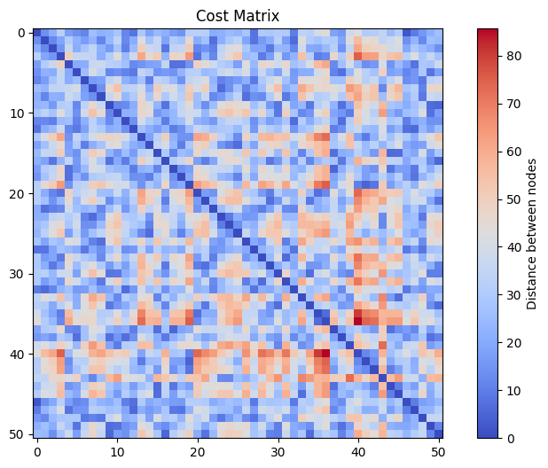

```python
# Cost matrix
coord, dem = choose_file()
dist = calculate_distance_matrix(coord)

# Plot cost matrix as a heatmap
plt.figure(figsize=(10,6))
plt.imshow(dist, cmap= 'coolwarm')
plt.colorbar(label='Distance between nodes')
plt.title('Cost Matrix')
plt.show()
```

### Defining the solver

```python
cost_matrix = dist
demand = dem
capacity = 160
```

```python
import numpy as np
import pyomo.environ as pyEnv

def solve_CVRP():

    global cost_matrix, demand, capacity

    n = len(cost_matrix)

    # Model
    model = pyEnv.ConcreteModel()

    # Indexes for the nodes
    model.M = pyEnv.RangeSet(n)
    model.N = pyEnv.RangeSet(n)

    # Decision variables xij
    model.x = pyEnv.Var(model.N, model.M, within=pyEnv.Binary)

    # Demand for each node
    model.demand = pyEnv.Param(model.N, initialize=lambda model, i: demand[i - 1])

    # Vehicle capacity
    model.capacity = pyEnv.Param(initialize=capacity)

    # Cost Matrix cij
    model.c = pyEnv.Param(model.N, model.M, initialize=lambda model, i, j: cost_matrix[i - 1][j - 1])

    def obj_func(model):
        return sum(model.x[i, j] * model.c[i, j] for i in model.N for j in model.M)

    model.objective = pyEnv.Objective(rule=obj_func, sense=pyEnv.minimize)

    def rule_const1(model):
        return sum(model.x[i, j] for i in model.N for j in model.M if i != j) == 1

    model.const1 = pyEnv.Constraint(rule=rule_const1)

#    def rule_const2(model, N):
#        return sum(model.x[N, j] for j in model.M if j != N) == 1

#    model.rest2 = pyEnv.Constraint(model.N, rule=rule_const2)

    def rule_const3(model):
        return sum(model.demand[j] * model.x[i,j] for i in model.M for j in model.N if i != j) <= model.capacity

    model.rest3 = pyEnv.Constraint(rule=rule_const3)

    def rule_const4(model):
        return sum(model.x[1, j] for j in model.N if j != 1) == 1

    model.rest4 = pyEnv.Constraint(rule=rule_const4)

    def rule_const5(model):
        return sum(model.x[i, 1] for i in model.N if i != 1) == 1

    model.rest5 = pyEnv.Constraint(rule=rule_const5)

    def rule_const6(model):
        a = sum(model.x[i, j] for i in model.M for j in model.N if i != j)
        b = sum(model.x[j, i] for i in model.M for j in model.N if i != j)
        return a - b == 0

    model.rest6 = pyEnv.Constraint(rule=rule_const6)

    # Solve using the Cplex engine
    solver = pyEnv.SolverFactory('cplex')
    result = solver.solve(model, tee=True)
```

```python
solve_CVRP()
```

Unfortunately, we were having some issues trying to run this cell as apparently there are some coding issue. We decided to opt for a different approach (seen in the cell below), but it demanded too much computacional effort so we could not get the optimal route despite showing that there are several solutions.

```python
import time
import numpy as np
import pyomo.environ as pyEnv
import matplotlib.pyplot as plt
import matplotlib as mpl
import networkx as nx

def solve_CVRP():

    global cost_matrix, demand, capacity

    n = len(cost_matrix)

    # Number of Vehicles
    n_vehicles = 15

    # Model
    model = pyEnv.ConcreteModel()

    model.V = pyEnv.Set(initialize=range(len(demand)))
    model.A = pyEnv.Set(initialize=[(i, j) for i in model.V for j in model.V if i != j])
    model.K = pyEnv.Set(initialize=range(n_vehicles))

    # Decision variables xijk and yik
    model.x = pyEnv.Var(model.A, model.K, within=pyEnv.Binary)
    model.y = pyEnv.Var(model.V, model.K, within=pyEnv.Binary)

    # Demand for each node
    model.demand = pyEnv.Param(model.V, initialize={i: d for (i, d) in enumerate(demand)})

    # Vehicle capacity
    model.capacity = pyEnv.Param(initialize=capacity)

    # Cost Matrix cij
    model.c = pyEnv.Param(model.A, initialize={(i, j): cost_matrix[i, j] for (i, j) in model.A})

    # Objective Function
    model.objective = pyEnv.Objective(
        expr=sum(
            model.x[i, j, k] * model.c[i, j]
            for (i, j) in model.A
            for k in model.K
        ),
        sense=pyEnv.minimize,
    )

    # Constraints

    def arcs_in(model, i):
        if i == model.V.first():
            return sum(model.x[:, i, :]) == len(model.K)
        else:
            return sum(model.x[:, i, :]) == 1.0


    def arcs_out(model, i):
        if i == model.V.first():
            return sum(model.x[i, :, :]) == len(model.K)
        else:
            return sum(model.x[i, :, :]) == 1.0


    def vehicle_assignment(model, i, k):
        return sum(model.x[:, i, k]) == model.y[i, k]


    def comp_vehicle_assignment(model, i, k):
        return sum(model.x[i, :, k]) == model.y[i, k]


    def capacity_constraint(model, k):
        return sum(model.y[i, k] * model.demand[i] for i in model.V) <= model.capacity


    model.arcs_in = pyEnv.Constraint(model.V, rule=arcs_in)
    model.arcs_out = pyEnv.Constraint(model.V, rule=arcs_out)
    model.vehicle_assignment = pyEnv.Constraint(model.V, model.K, rule=vehicle_assignment)
    model.comp_vehicle_assignment = pyEnv.Constraint(model.V, model.K, rule=comp_vehicle_assignment)
    model.capacity_constraint = pyEnv.Constraint(model.K, rule=capacity_constraint)


    def subtour_elimination(model, S, Sout, h, k):
        nodes_out = sum(model.x[i, j, k] for i in S for j in Sout)
        return model.y[h, k] <= nodes_out

    model.subtour_elimination = pyEnv.ConstraintList()


    def find_arcs(model):
        arcs = []
        for i, j in model.A:
            for k in model.K:
                if np.isclose(model.x[i, j, k].value, 1):
                    arcs.append((i, j))
        return arcs


    def find_subtours(arcs):
        G = nx.DiGraph(arcs)
        subtours = list(nx.strongly_connected_components(G))
        return subtours


    def eliminate_subtours(model, subtours):
        proceed = False
        for S in subtours:
            if 0 not in S:
                proceed = True
                Sout = {i for i in model.V if i not in S}
                for h in S:
                    for k in model.K:
                        model.subtour_elimination.add(
                          subtour_elimination(model, S, Sout, h, k)
                        )
        return proceed



    def solve_step(model, solver):
        sol = solver.solve(model,tee=True)
        arcs = find_arcs(model)
        subtours = find_subtours(arcs)
        time.sleep(0.1)
        proceed = eliminate_subtours(model, subtours)
        return sol, proceed


    def solve(model, solver):
        proceed = True
        while proceed:
            sol, proceed = solve_step(model, solver)
        return sol

    solver = pyEnv.SolverFactory('cplex')

    solution = solve(model, solver)

    def find_tours(model):
        tours = []
        for k in model.K:
            node = 0
            tours.append([0])
            while True:
                for j in model.V:
                    if (node, j) in model.A:
                        if np.isclose(model.x[node, j, k].value, 1):
                            node = j
                            tours[-1].append(node)
                            break
                if node == 0:
                    break
        return tours
```

```python
solve_CVRP()
```

```
Welcome to IBM(R) ILOG(R) CPLEX(R) Interactive Optimizer 22.1.1.0
  with Simplex, Mixed Integer & Barrier Optimizers
5725-A06 5725-A29 5724-Y48 5724-Y49 5724-Y54 5724-Y55 5655-Y21
Copyright IBM Corp. 1988, 2022.  All Rights Reserved.

Type 'help' for a list of available commands.
Type 'help' followed by a command name for more
information on commands.

CPLEX> Logfile 'cplex.log' closed.
Logfile 'C:\Users\jpmrr\AppData\Local\Temp\tmpspwu5qjn.cplex.log' open.
CPLEX> Problem 'C:\Users\jpmrr\AppData\Local\Temp\tmp23wv8kh8.pyomo.lp' read.
Read time = 0.05 sec. (3.18 ticks)
CPLEX> Problem name         : C:\Users\jpmrr\AppData\Local\Temp\tmp23wv8kh8.pyomo.lp
Objective sense      : Minimize
Variables            :   39015  [Binary: 39015]
Objective nonzeros   :   38250
Linear constraints   :    1647  [Less: 15,  Equal: 1632]
  Nonzeros           :  155280
  RHS nonzeros       :     117

Variables            : Min LB: 0.000000         Max UB: 1.000000
Objective nonzeros   : Min   : 2.236068         Max   : 85.63294
Linear constraints   :
  Nonzeros           : Min   : 1.000000         Max   : 41.00000
  RHS nonzeros       : Min   : 1.000000         Max   : 160.0000
CPLEX> Version identifier: 22.1.1.0 | 2022-11-27 | 9160aff4d
Tried aggregator 1 time.
MIP Presolve eliminated 0 rows and 15 columns.
MIP Presolve modified 1500 coefficients.
Reduced MIP has 1645 rows, 39000 columns, and 153750 nonzeros.
Reduced MIP has 39000 binaries, 0 generals, 0 SOSs, and 0 indicators.
Presolve time = 0.12 sec. (100.45 ticks)
Found incumbent of value 1848.622533 after 0.72 sec. (440.75 ticks)
Tried aggregator 1 time.
Detecting symmetries...
Reduced MIP has 1645 rows, 39000 columns, and 153750 nonzeros.
Reduced MIP has 39000 binaries, 0 generals, 0 SOSs, and 0 indicators.
Presolve time = 0.17 sec. (129.70 ticks)
Probing time = 0.12 sec. (19.72 ticks)
```

[output cut: 2087 more lines]

```
   9323  3147      705.8194   253      711.4304      704.1714  2673240    1.02%
   9584  3315        cutoff            711.4304      704.3659  2741532    0.99%
*  9717  3581      integral     0      711.3717      704.5428  2861950    0.96%
   9886  3578    infeasible            711.3717      704.5697  2857093    0.96%
  10314  3780      711.0947   223      711.3717      704.7806  2947649    0.93%
  10820  3838      710.0301   179      711.3717      704.9249  2984695    0.91%
  11191  4185        cutoff            711.3717      705.0247  3113919    0.89%
Elapsed time = 1058.00 sec. (292589.47 ticks, tree = 112.07 MB, solutions = 26)
  11460  4379      707.0109   234      711.3717      705.0604  3222602    0.89%
  11694  4503      710.5269   190      711.3717      705.2131  3293159    0.87%
  12058  4532      708.7490   113      711.3717      705.3143  3303391    0.85%
  12577  4636      706.1979   287      711.3717      705.3834  3361537    0.84%
  12989  4796        cutoff            711.3717      705.5257  3450994    0.82%
  13296  4995      707.3429   344      711.3717      705.6037  3541626    0.81%
  13532  5201        cutoff            711.3717      705.7379  3659416    0.79%
```